# FE515

## 1.4 Histograms of daily and weekly log returns

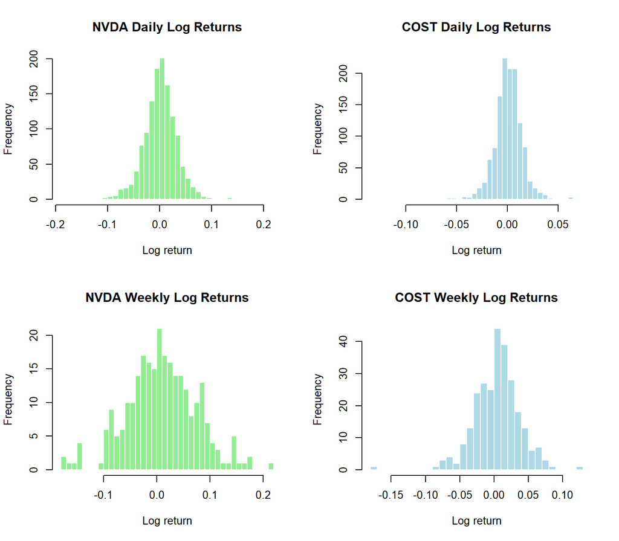

```r
par(mfrow = c(2, 2))
hist(coredata(ret_d[, "NVDA"]), breaks = 50, col = "lightgreen", border = "white",
     main = "NVDA Daily Log Returns", xlab = "Log return")
hist(coredata(ret_d[, "COST"]), breaks = 50, col = "lightblue", border = "white",
     main = "COST Daily Log Returns", xlab = "Log return")
hist(coredata(ret_w[, "NVDA"]), breaks = 30, col = "lightgreen", border = "white",
     main = "NVDA Weekly Log Returns", xlab = "Log return")
hist(coredata(ret_w[, "COST"]), breaks = 30, col = "lightblue", border = "white",
     main = "COST Weekly Log Returns", xlab = "Log return")
```

```r
par(mfrow = c(1, 1))
```

## 1.5 First four moments of daily log returns

You compute the four moments for each stock:

Mean: the average daily return. Variance: how spread out returns are, which is the usual measure of volatility. Skewness: whether big moves lean toward gains (positive) or losses (negative). Kurtosis: how heavy the tails are. A normal distribution has 3, so higher means more extreme days. Skewness and kurtosis are computed from the standardized central moments (population version). Kurtosis is reported as raw kurtosis (a normal distribution has 3); excess kurtosis is also shown.

```r
moment_stats <- function(x) {
  x  <- as.numeric(x)
  m  <- mean(x)
  v  <- var(x)
  n  <- length(x)
  s  <- sqrt(sum((x - m)^2) / n)          # population sd for standardizing
  sk <- sum((x - m)^3) / n / s^3
  ku <- sum((x - m)^4) / n / s^4
  c(Mean = m, Variance = v, Skewness = sk, Kurtosis = ku, `Excess Kurtosis` = ku - 3)
}

moments_df <- data.frame(
  Stock = tickers,
  t(sapply(tickers, function(tk) moment_stats(ret_d[, tk]))),
  row.names = NULL, check.names = FALSE
)

kable(moments_df, digits = 6, caption = "First four moments of daily log returns")
```

First four moments of daily log returns

| Stock | Mean | Variance | Skewness | Kurtosis | Excess Kurtosis |
| --- | --- | --- | --- | --- | --- |
| NVDA | 0.002016 | 0.001050 | 0.229795 | 6.655224 | 3.655224 |
| COST | 0.000800 | 0.000203 | -0.810501 | 11.855079 | 8.855079 |

## 1.6 Interpretation

```r
mv  <- setNames(moments_df$Variance, moments_df$Stock)
msk <- setNames(moments_df$Skewness, moments_df$Stock)
mku <- setNames(moments_df$Kurtosis, moments_df$Stock)
more_vol <- names(which.max(mv))
mv
```

```
##         NVDA         COST
## 0.0010502530 0.0002028192
```

```r
msk
```

```
##       NVDA       COST
##  0.2297952 -0.8105012
```

```r
mku
```

```
##      NVDA      COST
##  6.655224 11.855079
```

```r
more_vol
```

```
## [1] "NVDA"
```

Volatility. NVDA is the more volatile stock, with a daily standard deviation of about 3.24% versus about 1.42% for COST.

Skewness. NVDA’s skewness (0.23) is slightly positive, so its return distribution is nearly symmetric with a mild lean toward large gains. COST’s skewness (-0.81) is clearly negative, meaning its extreme moves are more often large losses than large gains.

Kurtosis. Both stocks have kurtosis well above 3 (NVDA 6.66, COST 11.86), so large gains and losses occur much more often than a normal distribution would predict. COST has the fatter tails despite lower overall volatility: it is usually calm but is prone to occasional sharp moves.

Conclusion. NVDA is riskier on a day-to-day basis, while COST’s risk is concentrated in rare, large downside shocks. For both stocks the return distribution suggests frequent extreme events, so normal-distribution assumptions would understate tail risk.

## 1.7 Correlation of daily log returns

```r
cor_d <- cor(ret_d[, 1], ret_d[, 2])
cor_d
```

```
##          COST
## NVDA 0.364447
```

The two stocks tend to move in the same direction on market-wide days, but only loosely. About 13% of the variation in one is explained by the other (0.36² ≈ 0.13), so most of each stock’s movement is driven by its own factors. They are neither strongly linked nor independent.

## 1.8 Equally weighted portfolio

I assume a 50/50 portfolio that is rebalanced daily, so the portfolio’s simple return is the average of the two simple returns. The portfolio log return is then

$$r_{p,t} = \ln\left(0.5\,e^{r_{1,t}} +
0.5\,e^{r_{2,t}}\right).$$

```r
w <- c(0.5, 0.5)
port_ret <- xts(log(as.numeric(exp(ret_d) %*% w)), order.by = index(ret_d))
colnames(port_ret) <- "Portfolio"
head(port_ret)
```

```
##                Portfolio
## 2021-01-05  0.0052904711
## 2021-01-06 -0.0377933220
## 2021-01-07  0.0257433331
## 2021-01-08  0.0002251806
## 2021-01-11  0.0049559946
## 2021-01-12 -0.0047698764
```

## 1.9 Portfolio vs. individual stocks

```r
all_ret <- merge(ret_d, port_ret)

compare_df <- data.frame(
  Asset    = colnames(all_ret),
  Mean     = sapply(all_ret, function(x) mean(x)),
  Variance = sapply(all_ret, function(x) var(x)),
  StdDev   = sapply(all_ret, function(x) sd(x)),
  row.names = NULL
)
kable(compare_df, digits = 6, caption = "Mean and variance: individual stocks vs. portfolio")
```

Mean and variance: individual stocks vs. portfolio

| Asset | Mean | Variance | StdDev |
| --- | --- | --- | --- |
| NVDA | 0.002016 | 0.001050 | 0.032408 |
| COST | 0.000800 | 0.000203 | 0.014241 |
| Portfolio | 0.001523 | 0.000398 | 0.019962 |

```r
pv <- compare_df$Variance[compare_df$Asset == "Portfolio"]
vols <- compare_df$Variance[compare_df$Asset %in% tickers]
names(vols) <- tickers
```

**Comment.** The portfolio’s mean return lies between the two individual means (it is roughly their average). Its variance is 3.98^{-4}, which is lower than the variance of the more volatile stock, and above the variance of the less volatile stock. Because the correlation is well below 1, the idiosyncratic movements partially offset one another. So diversification does reduce risk relative to holding the riskier stock alone, while still earning a return in between the two assets.

## 1.10 Cumulative growth of $100

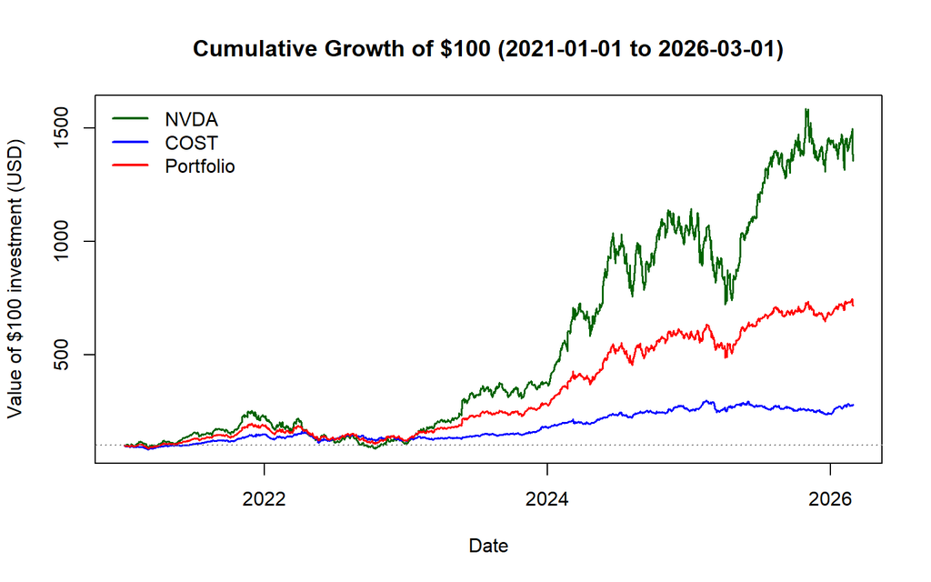

```r
growth <- 100 * exp(cumsum(all_ret))   # cumulative log returns -> growth of $100
# prepend the starting value of 100
start_row <- xts(matrix(100, nrow = 1, ncol = ncol(growth),
                        dimnames = list(NULL, colnames(growth))),
                 order.by = index(growth)[1] - 1)
growth <- rbind(start_row, growth)

cols <- c("darkgreen", "blue", "red")
plot(zoo(growth[, 1]), col = cols[1], lwd = 1.5, ylim = range(growth),
     xlab = "Date", ylab = "Value of $100 investment (USD)",
     main = "Cumulative Growth of $100 (2021-01-01 to 2026-03-01)")
lines(zoo(growth[, 2]), col = cols[2], lwd = 1.5)
lines(zoo(growth[, 3]), col = cols[3], lwd = 1.5)
abline(h = 100, lty = 3, col = "grey50")
legend("topleft", legend = colnames(growth), col = cols, lwd = 2, bty = "n")
```

```r
final_vals <- round(as.numeric(last(growth)), 2)
names(final_vals) <- colnames(growth)
kable(data.frame(Investment = names(final_vals), `Final Value ($)` = final_vals,
                 check.names = FALSE), row.names = FALSE)
```

| Investment | Final Value ($) |
| --- | --- |
| NVDA | 1355.00 |
| COST | 281.40 |
| Portfolio | 716.16 |

NVDA performed best. $100 grew to about $1,355 (roughly 13.6x), well ahead of the equally weighted portfolio at $716 (7.2x) and COST at $281 (2.8x).

# Question 2: Extreme Market Movements (Tail Risk)

## 2.1 New stock and extreme returns

I choose **TSLA**, a stock known for large price moves.

```r
getSymbols("TSLA", src = "yahoo", from = start_date, to = to_date, auto.assign = TRUE)
```

```
## [1] "TSLA"
```

```r
tsla_price <- na.omit(Ad(TSLA))
colnames(tsla_price) <- "TSLA"

tsla_ret <- na.omit(diff(log(tsla_price)))
colnames(tsla_ret) <- "TSLA"

mu_t    <- mean(tsla_ret)
sigma_t <- sd(tsla_ret)
threshold <- 3 * sigma_t

c(mean = mu_t, sd = sigma_t, `3 sd threshold` = threshold)
```

```
##           mean             sd 3 sd threshold
##    0.000389484    0.037714557    0.113143670
```

```r
# Absolute daily log return exceeds 3 * sd
extreme <- tsla_ret[abs(tsla_ret) > threshold]
```

## 2.2 Table of extreme returns

```r
extreme_df <- data.frame(Date = index(extreme),
                         `Log Return` = as.numeric(extreme),
                         `Number of SDs` = as.numeric(extreme) / sigma_t,
                         check.names = FALSE)
kable(extreme_df, digits = 4, row.names = FALSE,
      caption = "TSLA days with |daily log return| > 3 standard deviations")
```

TSLA days with |daily log return| > 3 standard deviations

| Date | Log Return | Number of SDs |
| --- | --- | --- |
| 2021-03-09 | 0.1793 | 4.7549 |
| 2021-10-25 | 0.1192 | 3.1611 |
| 2021-11-09 | -0.1277 | -3.3866 |
| 2022-01-03 | 0.1269 | 3.3651 |
| 2022-01-27 | -0.1228 | -3.2555 |
| 2022-04-26 | -0.1299 | -3.4450 |
| 2022-12-27 | -0.1211 | -3.2120 |
| 2023-01-03 | -0.1306 | -3.4626 |
| 2024-01-25 | -0.1293 | -3.4273 |
| 2024-04-24 | 0.1139 | 3.0194 |
| 2024-04-29 | 0.1424 | 3.7765 |
| 2024-07-24 | -0.1316 | -3.4905 |
| 2024-10-24 | 0.1982 | 5.2549 |
| 2024-11-06 | 0.1376 | 3.6483 |
| 2025-03-10 | -0.1675 | -4.4425 |
| 2025-04-09 | 0.2045 | 5.4221 |
| 2025-06-05 | -0.1538 | -4.0793 |

## 2.3 Proportion of observations beyond ±3σ

```r
n_total   <- length(tsla_ret)
n_extreme <- nrow(extreme_df)
prop_emp  <- n_extreme / n_total

c(`Total observations` = n_total, `Extreme days` = n_extreme, Proportion = prop_emp)
```

```
## Total observations       Extreme days         Proportion
##       1.293000e+03       1.700000e+01       1.314772e-02
```

## 2.4 Comparison with the normal distribution

```r
prop_norm <- 2 * pnorm(-3)   # P(|Z| > 3)
data.frame(Source = c("Empirical (TSLA)", "Normal distribution"),
           Proportion = c(prop_emp, prop_norm),
           `Expected number of days` = c(n_extreme, prop_norm * n_total),
           check.names = FALSE)
```

```
##                Source  Proportion Expected number of days
## 1    Empirical (TSLA) 0.013147718               17.000000
## 2 Normal distribution 0.002699796                3.490836
```

Under a normal distribution, only about 0.27% of days (about 3.5 of 1,293) should fall beyond ±3σ. TSLA has 17 such days (1.31%), roughly 4.9 times the theoretical frequency. Several moves exceed 4σ and 5σ, which a normal distribution would essentially rule out. TSLA therefore shows fat tails: extreme gains and losses happen much more often than the normal model predicts.

## 2.5 Why extreme returns matter

Extreme returns drive most of the real losses (and gains) investors experience, and they occur more often than normal-distribution models suggest. Identifying them matters because:

- Risk measures that assume normality (e.g., plain Gaussian VaR) can badly understate tail risk, so position sizing, stop-loss rules and capital buffers may be too small.
- Large losses can trigger margin calls, forced liquidations and breaches of risk limits, and a single extreme day can erase months of gains.
- Stress testing, scenario analysis, and tail-aware measures (Expected Shortfall, fat-tailed models, options hedging) rely on knowing how large and how frequent extremes are.
- Extremes often cluster around news, earnings and market stress, which informs event risk management and diversification decisions.

# Question 3: Simulating a Stock Return Distribution

## 3.1 Simulate 10,000 normal returns

I use the daily log returns of **NVDA** from Question 1.

```r
nvda_ret <- as.numeric(ret_d[, "NVDA"])
mu_n    <- mean(nvda_ret)
sigma_n <- sd(nvda_ret)

sim_ret <- rnorm(10000, mean = mu_n, sd = sigma_n)
```

## 3.2 Histogram of simulated returns

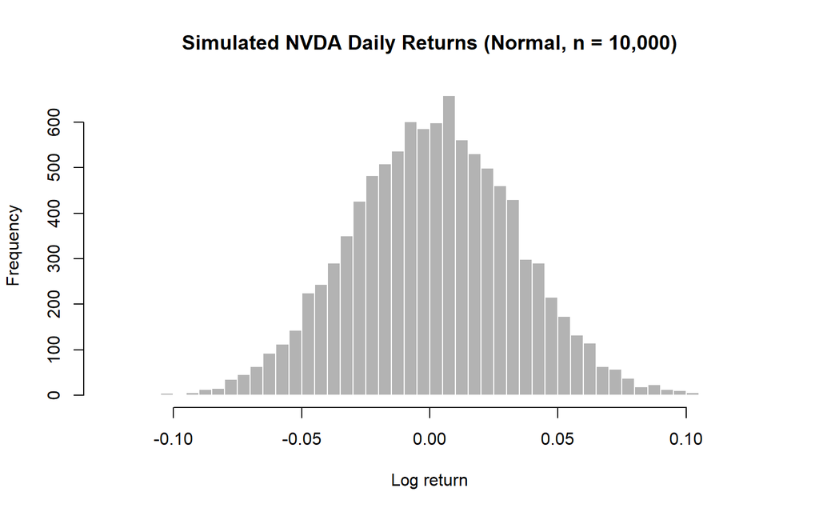

```r
hist(sim_ret, breaks = 60, col = "grey70", border = "white",
     main = "Simulated NVDA Daily Returns (Normal, n = 10,000)",
     xlab = "Log return")
```

## 3.3 Actual vs. simulated returns

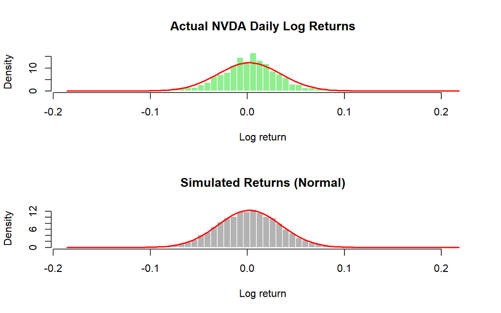

```r
xlim_rng <- range(c(nvda_ret, sim_ret))
brks <- seq(xlim_rng[1], xlim_rng[2], length.out = 61)

par(mfrow = c(2, 1))
hist(nvda_ret, breaks = brks, col = "lightgreen", border = "white", freq = FALSE,
     main = "Actual NVDA Daily Log Returns", xlab = "Log return")
curve(dnorm(x, mu_n, sigma_n), add = TRUE, col = "red", lwd = 2)
hist(sim_ret, breaks = brks, col = "grey70", border = "white", freq = FALSE,
     main = "Simulated Returns (Normal)", xlab = "Log return")
curve(dnorm(x, mu_n, sigma_n), add = TRUE, col = "red", lwd = 2)
```

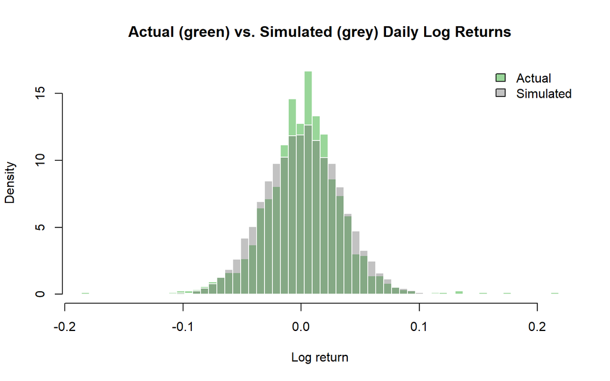

```r
par(mfrow = c(1, 1))

# Overlay on one plot for direct comparison
hist(nvda_ret, breaks = brks, freq = FALSE, col = rgb(0, 0.6, 0, 0.4), border = "white",
     main = "Actual (green) vs. Simulated (grey) Daily Log Returns", xlab = "Log return")
hist(sim_ret, breaks = brks, freq = FALSE, col = rgb(0.4, 0.4, 0.4, 0.4),
     border = "white", add = TRUE)
legend("topright", legend = c("Actual", "Simulated"),
       fill = c(rgb(0, 0.6, 0, 0.4), rgb(0.4, 0.4, 0.4, 0.4)), bty = "n")
```

The actual returns are typically **more peaked in the center** and have **heavier tails** than the simulated normal returns: more observations near zero and more observations far out on both sides.

## 3.4 Mean and variance comparison

```r
comp <- data.frame(
  Statistic = c("Mean", "Variance", "Std. Dev.", "Min", "Max", "Skewness", "Kurtosis"),
  Actual = c(mean(nvda_ret), var(nvda_ret), sd(nvda_ret), min(nvda_ret), max(nvda_ret),
             moment_stats(nvda_ret)["Skewness"], moment_stats(nvda_ret)["Kurtosis"]),
  Simulated = c(mean(sim_ret), var(sim_ret), sd(sim_ret), min(sim_ret), max(sim_ret),
                moment_stats(sim_ret)["Skewness"], moment_stats(sim_ret)["Kurtosis"])
)
kable(comp, digits = 6, caption = "Actual vs. simulated NVDA daily log returns")
```

Actual vs. simulated NVDA daily log returns

| Statistic | Actual | Simulated |
| --- | --- | --- |
| Mean | 0.002016 | 0.001494 |
| Variance | 0.001050 | 0.001047 |
| Std. Dev. | 0.032408 | 0.032356 |
| Min | -0.185946 | -0.121363 |
| Max | 0.218088 | 0.121478 |
| Skewness | 0.229795 | 0.005194 |
| Kurtosis | 6.655224 | 2.995404 |

## 3.5 Is the normal distribution a good model?

Conclusion: The normal distribution is a reasonable approximation for the center of the return distribution and for the first two moments, but it is not a good model for stock returns overall. It underestimates the frequency of extreme gains and losses, so risk measures based on it (such as Gaussian VaR) would understate tail risk. A fat-tailed model such as the Student-t distribution, a GARCH model, or historical simulation would be more appropriate.